# Part iA: Predictors (Lexicon: SentimentR)

INFSCI 2595 Final

Ben Stein

4/27/2022

# About this document

In this document, I perform exploratory data analysis on the variables from the SentimentR lexicon data.

# Setup

## Libraries and tools

```r
library(tidyverse)
source("./tools.R")
```

## Data

```r
df <- load_project_data() %>%
  select(response_log, outcome_numeric, starts_with("xs"))

df %>% glimpse
```

```
## Rows: 677
## Columns: 8
## $ response_log    <dbl> 0.9624073, 0.1694321, 0.7959862, 1.0030975, 0.3942847,~
## $ outcome_numeric <dbl> 0, 0, 1, 0, 0, 0, 0, 0, 0, 0, 0, 0, 0, 0, 0, 0, 0, 1, ~
## $ xs_01           <dbl> 0.262073307, 0.330804757, 0.239795763, 0.142106837, 0.~
## $ xs_02           <dbl> 0.26207331, 0.33080476, 0.19049123, -0.73321509, -0.12~
## $ xs_03           <dbl> 0.2620733, 0.3308048, 0.2891003, 0.5500723, 1.3134719,~
## $ xs_04           <dbl> 0.5375576, 0.4286607, 0.3676937, 0.2865445, 0.2375470,~
## $ xs_05           <dbl> 0.5375575604, 0.4286607050, 0.2485001680, 0.0000000000~
## $ xs_06           <dbl> 0.5375576, 0.4286607, 0.4868872, 0.6357541, 0.4327004,~
```

# Distributions

Let’s look at the distributions of the variables first.

```r
df %>%
  select(-outcome_numeric, -response_log) %>%
  summary
```

```
##      xs_01             xs_02              xs_03             xs_04
##  Min.   :-0.3612   Min.   :-0.89585   Min.   :-0.3612   Min.   :0.0000
##  1st Qu.: 0.1449   1st Qu.:-0.14236   1st Qu.: 0.2412   1st Qu.:0.2438
##  Median : 0.2160   Median : 0.03546   Median : 0.3870   Median :0.2908
##  Mean   : 0.2148   Mean   : 0.02228   Mean   : 0.4241   Mean   :0.3011
##  3rd Qu.: 0.2839   3rd Qu.: 0.19274   3rd Qu.: 0.5940   3rd Qu.:0.3429
##  Max.   : 0.7548   Max.   : 0.69105   Max.   : 1.7907   Max.   :0.8988
##      xs_05             xs_06
##  Min.   :0.00000   Min.   :0.0000
##  1st Qu.:0.07934   1st Qu.:0.3040
##  Median :0.16213   Median :0.4324
##  Mean   :0.18863   Mean   :0.4666
##  3rd Qu.:0.26336   3rd Qu.:0.5948
##  Max.   :0.89883   Max.   :1.3088
```

Somewhat unlike other groups of sentiment variables, the scales of these inputs are less different. Nevertheless, I’ll probably center and scale them, because I’m not sure if you ever *don’t* want to do that.

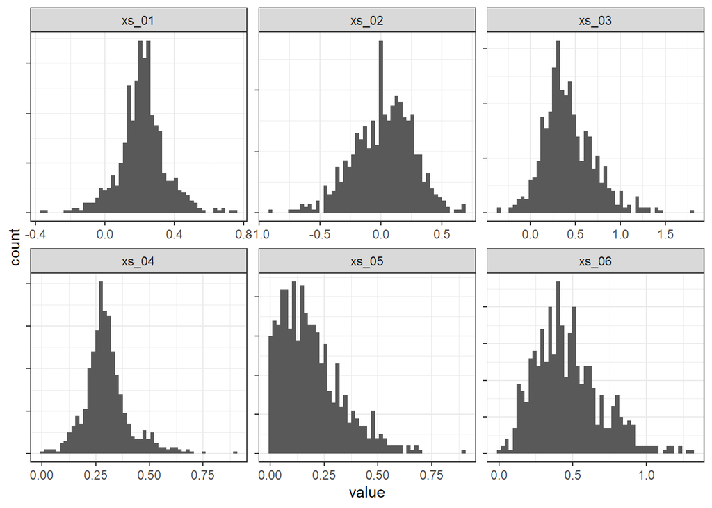

```r
visualize_distributions(df, "xs")
```

In this predictor group, some of the distributions are noticeably less normal (e.g. inputs 4 and 5, which seem right-tailed).

## Distinct values

As I worked with each group of continuous predictors, I noticed that some seem to have more unique values than others. Let’s quantify that:

```r
df %>%
  select(-outcome_numeric, -response_log) %>%
  pivot_longer(cols = everything()) %>%
  group_by(name) %>%
  unique %>%
  count
```

```
## # A tibble: 6 x 2
## # Groups:   name [6]
##   name      n
##   <chr> <int>
## 1 xs_01   676
## 2 xs_02   644
## 3 xs_03   672
## 4 xs_04   676
## 5 xs_05   663
## 6 xs_06   676
```

In this group, variables have very similar numbers of total distinct values, so it’s hard to infer whether one encodes more knowledge about the response/outcome than the others.

# Correlation within the group

Let’s see if any of these inputs are correlated with one another or with the response variable.

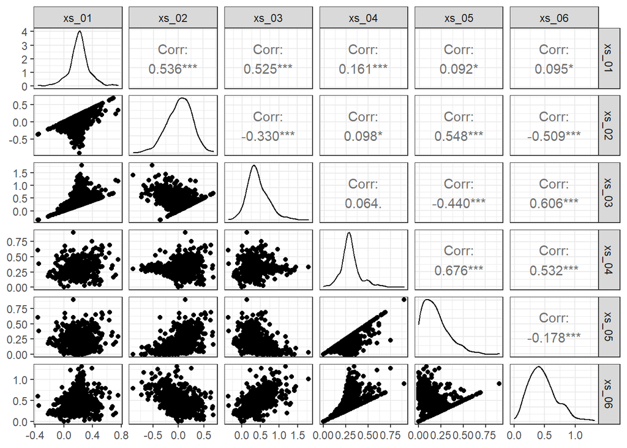

```r
visualize_correlations(df, "xs")
```

We can observe significant correlation between the predictors here - in particular, inputs 5 and 6 seem highly correlated with a few other inputs. Thus, they’re probably good candidates to exclude in refined modeling.

# Relationship to target variables

## The continuous `response` variable

Note that I log-transformed response since that’s what I’ll be predicting anyway.

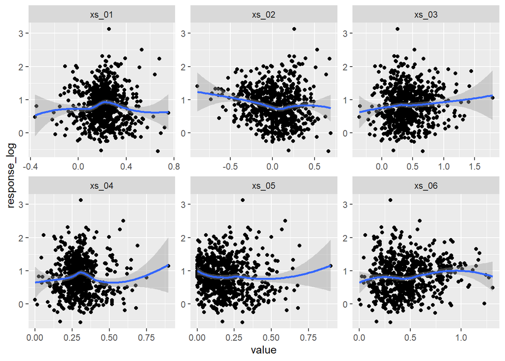

```r
df %>%
  pivot_longer(cols = starts_with("xs")) %>%
  ggplot(mapping = aes(x = value, y = response_log)) +
  geom_point() +
  geom_smooth(formula = y ~ x, method = "loess") +
  facet_wrap(~ name, scales = "free")
```

Like the other lexicons, the loess lines are nearly (but not exactly) linear. Based on this figure and the corresponding ones for other groups, I’m interested in using splines to model them.

## The `outcome` classification target

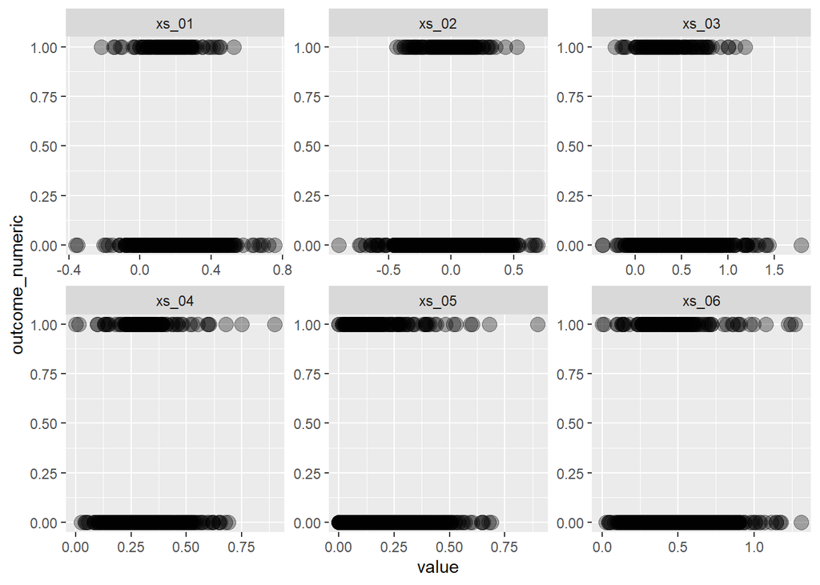

```r
df %>%
  select(-response_log) %>%
  pivot_longer(cols = starts_with("xs")) %>%
  ggplot(mapping = aes(x = value, y = outcome_numeric)) +
  geom_point(size = 4, alpha = .33) +
  facet_wrap(~ name, scales = "free")
```

What I take from this is that this group is not as useful for predicting `outcome` as some of the other sentiment-based predictor groups, as there is not a clear trend between values of each predictor and the outcome.